# Marginal Structural Models for Time-Varying Confounders

Nanum Jeon

2025-06-30

# Introduction

This tutorial focuses on **Marginal Structural Models (MSM)** using **Inverse Probability Weighting (IPW)** to estimate the average causal effects of always taking treatment compared to never taking treatment. MSMs provide an alternative to the g-formula for handling time-varying confounders and are particularly useful when modeling complex treatment-confounder relationships is challenging.

From our knowledge of the data-generating process, we know the true average causal effect to be **50**.

## Load Required Libraries

```r
library(dplyr)
library(knitr)
library(kableExtra)
library(ggplot2)
```

## Our Settings

The empirical setting is to treat HIV with a therapy regimen (A) in two time periods (t = 0, t = 1). We measure the time-varying confounder, HIV viral load (Z), at times t = 0 and t = 1. Our outcome is the CD4 count (cells/mm³) observed at t = 2.

**Objective**: Estimate the causal effect of always being treated vs. never being treated on HIV outcomes.

**Variables**:

- **A0, A1**: Treatment at times 0 and 1 (0 = no treatment, 1 = treatment)
- **Z0 = 1** for all subjects (high viral load at baseline); 1 indicates worse baseline condition.
- **Z1**: Time-varying confounder (HIV viral load at time 1; 0 = low, 1 = high)
- **Y**: Outcome (CD4 count at time 2); higher values indicate better immune function.

**Causal structure**: Z0 → A0 → Z1 → A1 → Y

**Target estimand**: E[Y^{1,1}] - E[Y^{0,0}] (always treated vs. never treated)

**Data Structure:** Z₀ → A₀ → Z₁ → A₁ → Y

We assume Z₀ = 1 (high viral load) for all subjects at baseline.

## Data Setup

```r
# Data in Table 1
# A0: Treatment at time 0 (for HIV)
# Z1: HIV viral load measurement prior to time 1 (Higher: Worse health condition)
# A1: Treatment at time 1
# Y: Mean of CD4 counts
# N: Number of subjects

a0 <- c(0, 0, 0, 0, 1, 1, 1, 1)
z1 <- c(0, 0, 1, 1, 0, 0, 1, 1)
a1 <- c(0, 1, 0, 1, 0, 1, 0, 1)
y <- c(87.288, 112.107, 119.654, 144.842, 105.282, 130.184, 137.720, 162.832)
n <- c(209271, 93779, 60657, 136293, 134781, 60789, 93903, 210527)

data <- data.frame(a0, z1, a1, y, n)

# Display the data
kable(data, caption = "Original Data Structure") %>%
  kable_styling(bootstrap_options = c("striped", "hover"))
```

Original Data Structure

| a0 | z1 | a1 | y | n |
| --- | --- | --- | --- | --- |
| 0 | 0 | 0 | 87.288 | 209271 |
| 0 | 0 | 1 | 112.107 | 93779 |
| 0 | 1 | 0 | 119.654 | 60657 |
| 0 | 1 | 1 | 144.842 | 136293 |
| 1 | 0 | 0 | 105.282 | 134781 |
| 1 | 0 | 1 | 130.184 | 60789 |
| 1 | 1 | 0 | 137.720 | 93903 |
| 1 | 1 | 1 | 162.832 | 210527 |

# Marginal Structural Models Approach

## Introduction to MSM

Marginal Structural Models map the marginal summary (e.g., average) of potential outcomes to treatment trajectories. Unlike the g-formula, MSMs require less modeling of time-varying variables by using inverse probability weighting to create a pseudo-population where treatment assignment is independent of confounders.

The MSM approach involves three key steps: 1. **Model treatment probabilities** at each time point 2. **Calculate inverse probability weights** 3. **Fit outcome model** using weighted data

## Step 1: Expand Data to Individual Level

First, we need to expand our aggregated data to individual-level observations for MSM analysis.

```r
# Expand data to individual level based on sample sizes
expanded_data <- data %>%
  rowwise() %>%
  do(data.frame(
    a0 = rep(.$a0, .$n),
    z1 = rep(.$z1, .$n),
    a1 = rep(.$a1, .$n),
    y = rep(.$y, .$n)
  )) %>%
  ungroup()

# Add individual IDs
expanded_data$id <- 1:nrow(expanded_data)

print(paste("Total individuals:", nrow(expanded_data)))
```

```
## [1] "Total individuals: 1000000"
```

```r
print("Random sample of individuals:")
```

```
## [1] "Random sample of individuals:"
```

```r
set.seed(123)  # For reproducible random sample
expanded_data %>%
  sample_n(10) %>%
  arrange(id) %>%
  kable() %>%
  kable_styling(bootstrap_options = c("striped", "hover"))
```

| a0 | z1 | a1 | y | id |
| --- | --- | --- | --- | --- |
| 0 | 0 | 0 | 87.288 | 124022 |
| 0 | 0 | 0 | 87.288 | 134058 |
| 0 | 0 | 0 | 87.288 | 188942 |
| 0 | 0 | 0 | 87.288 | 193627 |
| 0 | 0 | 1 | 112.107 | 226318 |
| 0 | 1 | 1 | 144.842 | 365209 |
| 1 | 0 | 1 | 130.184 | 648795 |
| 1 | 0 | 1 | 130.184 | 685285 |
| 1 | 1 | 1 | 162.832 | 969167 |
| 1 | 1 | 1 | 162.832 | 985797 |

## Step 2: Model Treatment Probabilities

We model the probability of receiving treatment at each time point conditional on past history.

```r
# Model for A0: Treatment at time 0
# Since Z0 = 1 for everyone, we model A0 as depending on baseline characteristics
# For simplicity, we'll model P(A0 = 1) as a constant
prob_a0_1 <- mean(expanded_data$a0)
print(paste("Probability of A0 = 1:", round(prob_a0_1, 4)))
```

```
## [1] "Probability of A0 = 1: 0.5"
```

```r
# Model for A1: Treatment at time 1 given Z1 and A0
a1_model <- glm(a1 ~ z1 + a0, family = binomial(), data = expanded_data)
summary(a1_model)
```

```
##
## Call:
## glm(formula = a1 ~ z1 + a0, family = binomial(), data = expanded_data)
##
## Deviance Residuals:
##     Min       1Q   Median       3Q      Max
## -1.5345  -0.8619   0.8583   0.8590   1.5309
##
## Coefficients:
##              Estimate Std. Error  z value Pr(>|z|)
## (Intercept) -0.800985   0.003521 -227.469   <2e-16 ***
## z1           1.607930   0.004431  362.884   <2e-16 ***
## a0           0.002107   0.004431    0.476    0.634
## ---
## Signif. codes:  0 '***' 0.001 '**' 0.01 '*' 0.05 '.' 0.1 ' ' 1
##
## (Dispersion parameter for binomial family taken to be 1)
##
##     Null deviance: 1386287  on 999999  degrees of freedom
## Residual deviance: 1236799  on 999997  degrees of freedom
## AIC: 1236805
##
## Number of Fisher Scoring iterations: 4
```

```r
# Predict treatment probabilities
expanded_data$prob_a0 <- ifelse(expanded_data$a0 == 1, prob_a0_1, 1 - prob_a0_1)
expanded_data$prob_a1_given_history <- predict(a1_model, type = "response")
expanded_data$prob_a1 <- ifelse(expanded_data$a1 == 1,
                                expanded_data$prob_a1_given_history,
                                1 - expanded_data$prob_a1_given_history)
```

## Step 3: Calculate Inverse Probability Weights

The inverse probability weights create a pseudo-population where treatment is independent of confounders.

```r
# Calculate inverse probability weights
expanded_data$ipw <- 1 / (expanded_data$prob_a0 * expanded_data$prob_a1)

# Check weight distributions
print("Weight Summary Statistics:")
```

```
## [1] "Weight Summary Statistics:"
```

```r
weight_summary <- expanded_data %>%
  summarise(
    Mean_IPW = mean(ipw),
    SD_IPW = sd(ipw),
    Min_IPW = min(ipw),
    Max_IPW = max(ipw)
  )

weight_summary %>%
  kable(digits = 4, caption = "Inverse Probability Weight Distribution Summary") %>%
  kable_styling(bootstrap_options = c("striped", "hover"))
```

Inverse Probability Weight Distribution Summary

| Mean_IPW | SD_IPW | Min_IPW | Max_IPW |
| --- | --- | --- | --- |
| 4 | 1.6521 | 2.8906 | 6.4916 |

## Step 4: Visualize Weight Distribution

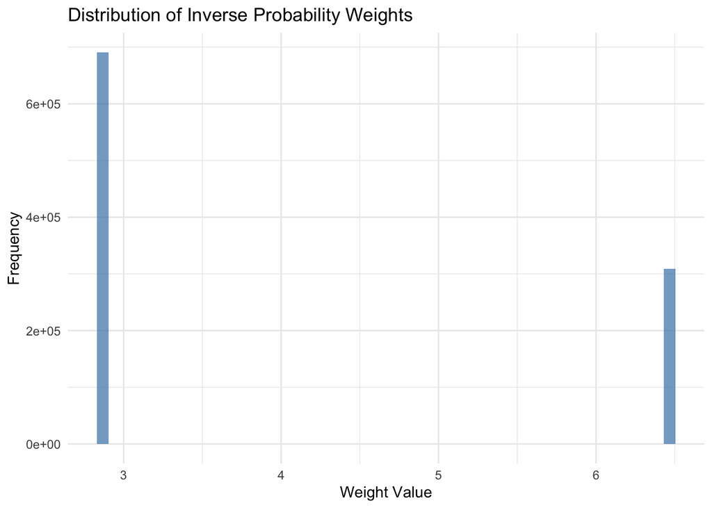

```r
# Create weight distribution plot
ggplot(expanded_data, aes(x = ipw)) +
  geom_histogram(alpha = 0.7, bins = 50, fill = "steelblue") +
  theme_minimal() +
  labs(title = "Distribution of Inverse Probability Weights",
       x = "Weight Value",
       y = "Frequency")
```

## Step 5: Fit Marginal Structural Model

Now we fit the outcome model using the weighted data to estimate causal effects.

```r
# Fit MSM using inverse probability weights
# The model directly estimates marginal causal effects
msm_model <- lm(y ~ a0 + a1, data = expanded_data, weights = ipw)

print("MSM Model Summary:")
```

```
## [1] "MSM Model Summary:"
```

```r
summary(msm_model)
```

```
##
## Call:
## lm(formula = y ~ a0 + a1, data = expanded_data, weights = ipw)
##
## Weighted Residuals:
##    Min     1Q Median     3Q    Max
## -50.42 -32.80  21.74  32.29  49.99
##
## Coefficients:
##              Estimate Std. Error t value Pr(>|t|)
## (Intercept) 100.01929    0.02753  3632.9   <2e-16 ***
## a0           25.02788    0.03179   787.4   <2e-16 ***
## a1           24.99712    0.03179   786.4   <2e-16 ***
## ---
## Signif. codes:  0 '***' 0.001 '**' 0.01 '*' 0.05 '.' 0.1 ' ' 1
##
## Residual standard error: 31.79 on 999997 degrees of freedom
## Multiple R-squared:  0.5533, Adjusted R-squared:  0.5533
## F-statistic: 6.192e+05 on 2 and 999997 DF,  p-value: < 2.2e-16
```

```r
# Extract coefficients for interpretation
coef_summary <- broom::tidy(msm_model)
kable(coef_summary, digits = 4, caption = "MSM Model Coefficients") %>%
  kable_styling(bootstrap_options = c("striped", "hover"))
```

MSM Model Coefficients

| term | estimate | std.error | statistic | p.value |
| --- | --- | --- | --- | --- |
| (Intercept) | 100.0193 | 0.0275 | 3632.9316 | 0 |
| a0 | 25.0279 | 0.0318 | 787.3820 | 0 |
| a1 | 24.9971 | 0.0318 | 786.4142 | 0 |

## Step 6: Estimate Causal Effects

Using the fitted MSM, we can estimate potential outcomes under different treatment regimens.

```r
# Create data for prediction under different treatment scenarios
scenario_data <- data.frame(
  scenario = c("Never treated", "Always treated", "Treated at t=0 only", "Treated at t=1 only"),
  a0 = c(0, 1, 1, 0),
  a1 = c(0, 1, 0, 1)
)

# Predict potential outcomes
scenario_data$potential_outcome <- predict(msm_model, newdata = scenario_data)

# Calculate causal effect: Always treated vs Never treated
tau_msm <- scenario_data$potential_outcome[2] - scenario_data$potential_outcome[1]

print(paste("MSM Estimated Causal Effect (τ):", round(tau_msm, 4)))
```

```
## [1] "MSM Estimated Causal Effect (τ): 50.025"
```

```r
print(paste("True Causal Effect:", 50))
```

```
## [1] "True Causal Effect: 50"
```

```r
print(paste("Bias:", round(tau_msm - 50, 4)))
```

```
## [1] "Bias: 0.025"
```

```r
# Display all scenarios
kable(scenario_data, digits = 4,
      caption = "Potential Outcomes Under Different Treatment Scenarios") %>%
  kable_styling(bootstrap_options = c("striped", "hover"))
```

Potential Outcomes Under Different Treatment Scenarios

| scenario | a0 | a1 | potential_outcome |
| --- | --- | --- | --- |
| Never treated | 0 | 0 | 100.0193 |
| Always treated | 1 | 1 | 150.0443 |
| Treated at t=0 only | 1 | 0 | 125.0472 |
| Treated at t=1 only | 0 | 1 | 125.0164 |

## Step 7: Check Balance After Weighting

One key advantage of IPW is that it should balance confounders across treatment groups in the weighted sample.

```r
# Check balance of Z1 across A1 groups
balance_check_a1 <- expanded_data %>%
  group_by(a1) %>%
  summarise(
    n = n(),
    mean_z1_unweighted = mean(z1),
    mean_z1_weighted = weighted.mean(z1, ipw),
    .groups = 'drop'
  )

print("Balance Check - Z1 by A1:")
```

```
## [1] "Balance Check - Z1 by A1:"
```

```r
kable(balance_check_a1, digits = 4,
      caption = "Balance of Z1 across A1 groups (Before and After Weighting)") %>%
  kable_styling(bootstrap_options = c("striped", "hover"))
```

Balance of Z1 across A1 groups (Before and After Weighting)

| a1 | n | mean_z1_unweighted | mean_z1_weighted |
| --- | --- | --- | --- |
| 0 | 498612 | 0.3100 | 0.5014 |
| 1 | 501388 | 0.6917 | 0.5014 |

```r
# Create comprehensive results table
results_summary <- data.frame(
  Method = c("True Effect", "MSM (Inverse Probability Weighting)"),
  Estimated_Effect = c(50, round(tau_msm, 4)),
  Bias = c(0, round(tau_msm - 50, 4))
)

kable(results_summary,
      caption = "Summary of Causal Effect Estimates",
      digits = 4) %>%
  kable_styling(bootstrap_options = c("striped", "hover"))
```

Summary of Causal Effect Estimates

| Method | Estimated_Effect | Bias |
| --- | --- | --- |
| True Effect | 50.000 | 0.000 |
| MSM (Inverse Probability Weighting) | 50.025 | 0.025 |

```r
cat("\n")
```

```r
cat("Key Findings:\n")
```

```
## Key Findings:
```

```r
cat("- MSM with inverse probability weighting provides a causal effect estimate\n")
```

```
## - MSM with inverse probability weighting provides a causal effect estimate
```

```r
cat("- IPW successfully balances confounders in the weighted pseudo-population\n")
```

```
## - IPW successfully balances confounders in the weighted pseudo-population
```

```r
cat("- MSM offers a flexible alternative to g-formula for time-varying confounders\n")
```

```
## - MSM offers a flexible alternative to g-formula for time-varying confounders
```

```r
cat("- Less modeling required compared to g-formula approach\n")
```

```
## - Less modeling required compared to g-formula approach
```

# Advantages and Limitations of MSM

## Advantages:

- **Less modeling required**: No need to model complex relationships for time-varying confounders
- **Intuitive interpretation**: Direct estimation of marginal causal effects
- **Flexibility**: Can handle complex treatment regimens
- **Balance checking**: Easy to verify that weighting achieves balance

## Limitations:

- **Positivity assumption**: Requires overlap in treatment probabilities
- **Weight variability**: Extreme weights can lead to instability
- **Model specification**: Still requires correct specification of treatment models
- **Large sample requirement**: Performance depends on adequate sample size

# Conclusion

Marginal Structural Models with Inverse Probability Weighting provide a powerful alternative to the g-formula for causal inference with time-varying confounders. The method creates a pseudo-population where treatment assignment is independent of confounders, allowing for unbiased estimation of causal effects.

In our HIV treatment example, MSM successfully estimated the causal effect of always being treated versus never being treated, demonstrating the practical utility of this approach for longitudinal causal inference.